# Data Visualization: Day 3

Erik Westlund

2025-06-12

# Housekeeping

## Course Evaluations

- JHSPH aims for 100% course evaluation completion
- Please complete the course evaluation by https://courseevalsystem.jhsph.edu/.
- I will follow up with an email reminder or tow.

## Problem Set 3 & Final Project

- The final problem set is due tomorrow.
- The final project is due in three weeks, on July 3rd.
- Review the final assignment sheet on CoursePlus or [GitHub](https://github.com/erikwestlund/data-viz-summer-25/blob/main/assignments/Final%20Project.docx)
- Submit all assignments via email or on CoursePlus
- I prefer you put your work in the `work` directory on your GitHub repository fork

## Final Project

- Email it to me or submit it on CoursePlus
- Basic requirements:
  - Submit a rendered notebook
  - Each visualizatoin needs a justification
  - 10 visualizations total
  - 5 can be univariate
  - 5 must have at least two variables
  - 2 must have three or more
  - Make them polished

## Support

- Please feel free to reach out to me via email or Teams
- I am happy to meet with you on Zoom to discuss your work and answer questions

## Overview for Day 3

# Day 3: What to Visualize – From Question to Plot

## Theme: Science Drives Visualization

- Data visualization is valuable for its scientific application
- It helps us:
  - Understand our data
  - Understand our models
  - Communicate our findings in an impactful way

# DAGs, Scientific Complexity, Causal Inference, and Visualization

## From Question to DAG to Plot

- We’ll start with a scientific question.
- We’ll sketch out the causal structure using a DAG.
- From this, we can assess typical problems scientific studies like this face
- We can then use the DAG to guide our visualization choices

## Scientific Question

“What causes mothers to receive comprehensive postnatal care?”

## Directed Acyclic Graphs

- A DAG is a graph that represents the causal relationships between variables.
- It is a directed graph, meaning that the edges have a direction.
- It is an acyclic graph, meaning that there are no cycles in the graph.
- It is a graph, meaning that it has nodes and edges.

## How DAGs Help Us In Science & Visualization

- DAGs help us:
  - Identify the variables that are important to the question
  - Identify the variables that are confounding
  - Identify the variables that are missing
  - Identify the variables that are measured incorrectly
- Having a good idea of the causal structure of a question helps us know what to visualize.

## DAGs as a Visualization Tool

- DAGs:
  1. are themselves visualizations
  2. encode scientific problems and causal structures
- We can use the `daggity` R package to visualize the the causal structure of the problems around the motivating research question

## Big Picture

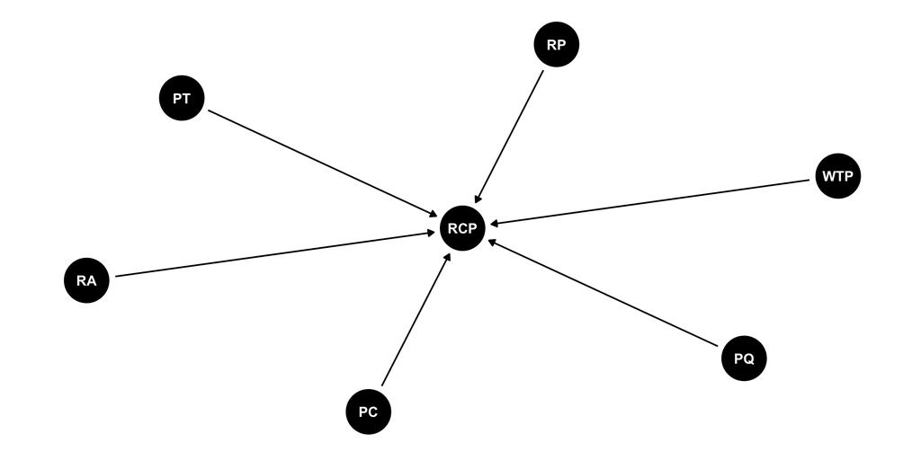

```r
rcp_dag <- dagify(RCP ~ PQ + PC + WTP + PT + RA + RP)

rcp_dag |>
    ggdag() +
    theme_dag()
```

- RCP = “Received Comprehensive Postnatal Care”
- PQ = “Provider Quality”
- PC = “Personal Capacity”
- WTP = “Willingness to Pay”
- PT = “Provider Trust”
- RA = “Risk Aversion”
- RP = “Risk Profile”

## Provider Quality (PQ) Sub-DAG

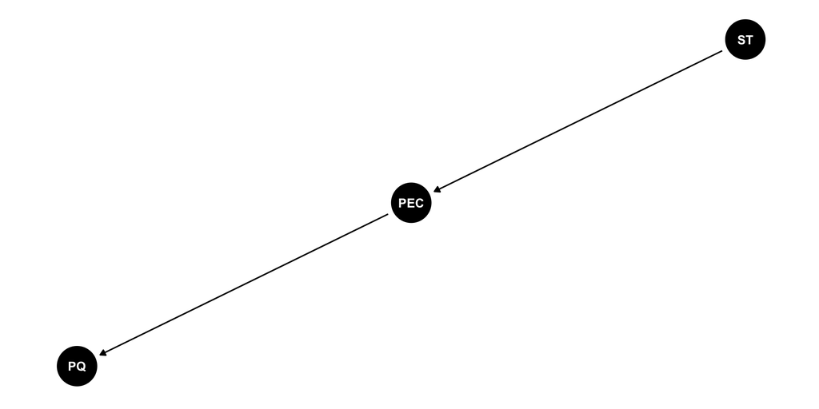

```r
pq_dag <- dagify(
  PQ ~ PEC,
  PEC ~ ST
)

pq_dag |>
    ggdag() +
    theme_dag()
```

- PQ = “Provider Quality”
- PEC = “Political/Economic Conditions”
- ST = “State”

## Personal Capacity (PC) Sub-DAG

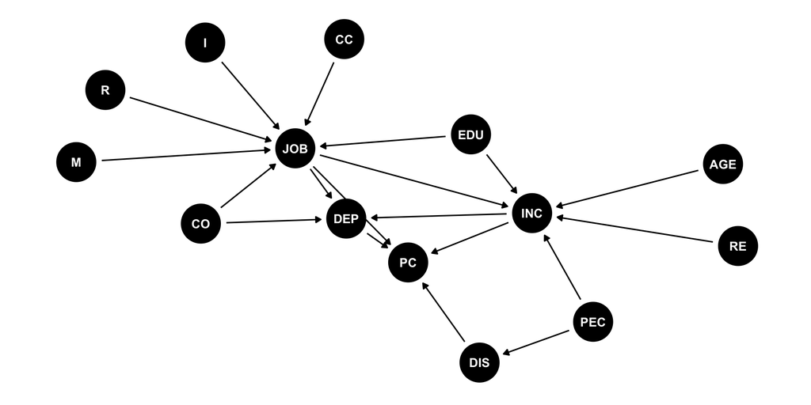

```r
pc_dag <- dagify(
  PC ~ DEP + JOB + INC + DIS,
  DEP ~ INC + JOB + CO,
  JOB ~ EDU + CO + R + M + I + CC,
  DIS ~ PEC,
  INC ~ JOB + EDU + RE + PEC + AGE
)

pc_dag |>
    ggdag() +
    theme_dag()
```

- PC = “Personal Capacity”
- DEP = “Dependents”
- JOB = “Job Type”
- INC = “Income”
- DIS = “Distance to Provider”
- CO = “Cultural Orientation”
- EDU = “Educational Attainment”
- R = “Resilience”
- M = “Motivation”
- I = “Intelligence”
- CC = “Community Connections”
- RE = “Race/Ethnicity”
- AGE = “Age”

## Willingness to Pay (WTP) Sub-DAG

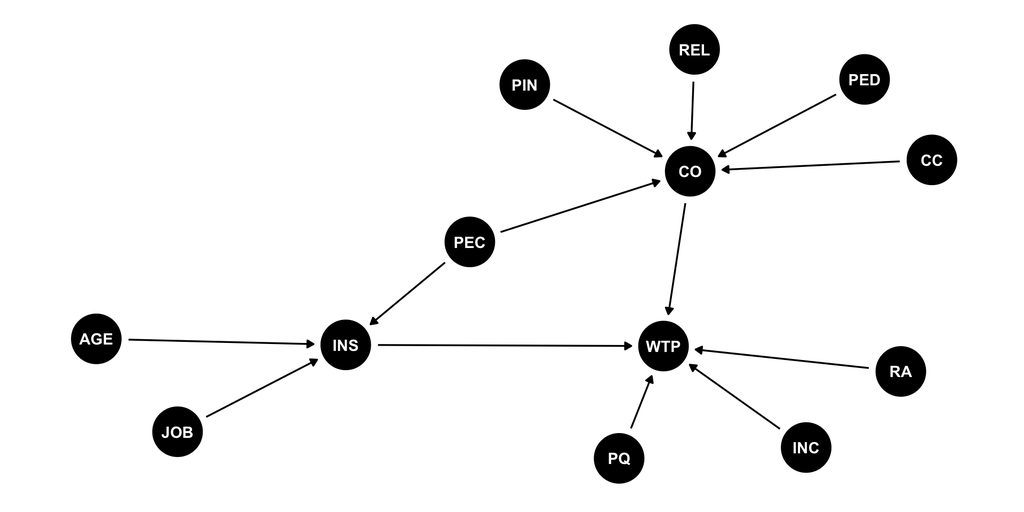

```r
wtp_dag <- dagify(
  WTP ~ PQ + INC + INS + RA + CO,
  INS ~ JOB + PEC + AGE,
  CO ~ PED + PIN + REL + PEC + CC
)

wtp_dag |>
    ggdag() +
    theme_dag()
```

- WTP = “Willingness to Pay”
- PQ = “Provider Quality”
- INC = “Income”
- INS = “Insurance”
- RA = “Risk Aversion”
- CO = “Cultural Orientation”
- JOB = “Job Type”
- PEC = “Political/Economic Conditions”
- AGE = “Age”
- PED = “Parent Education”
- PIN = “Parent Income”
- REL = “Religion”
- CC = “Community Connections”

## Provider Trust (PT) Sub-DAG

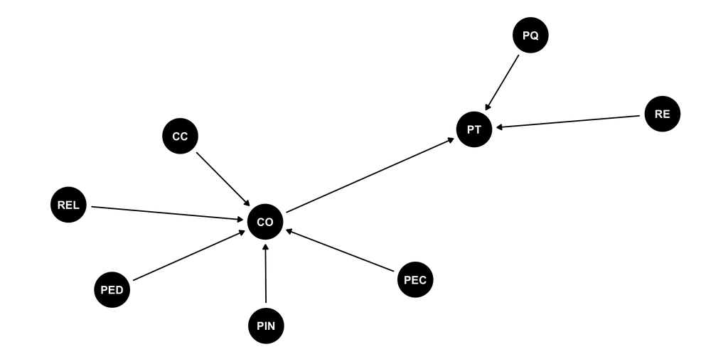

```r
pt_dag <- dagify(
  PT ~ PQ + RE + CO,
  CO ~ PED + PIN + REL + PEC + CC
)

pt_dag |>
    ggdag() +
    theme_dag()
```

- PT = “Provider Trust”
- PQ = “Provider Quality”
- RE = “Race/Ethnicity”
- CO = “Cultural Orientation”
- PED = “Parent Education”
- PIN = “Parent Income”
- REL = “Religion”
- PEC = “Political/Economic Conditions”
- CC = “Community Connections”

## Risk Aversion (RA) Sub-DAG

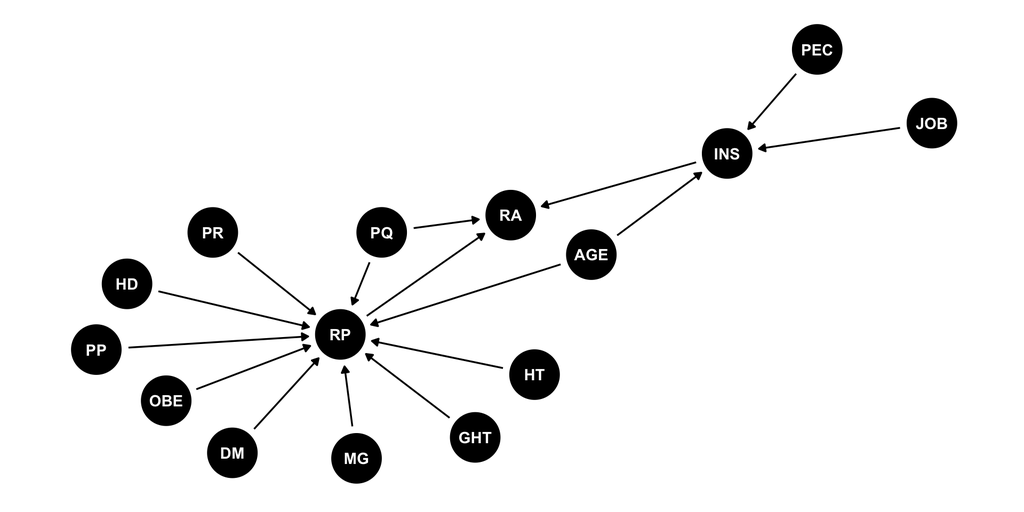

```r
ra_dag <- dagify(
  RA ~ PQ + RP + INS,
  RP ~ PQ + AGE + OBE + MG + DM + HD + PP + PR + HT + GHT,
  INS ~ JOB + PEC + AGE
)

ra_dag |>
    ggdag() +
    theme_dag()
```

- RA = “Risk Aversion”
- PQ = “Provider Quality”
- RP = “Risk Profile”
- INS = “Insurance”
- AGE = “Age”
- OBE = “Obesity”
- MG = “Multiple Gestation”
- DM = “Diabetes Mellitus”
- HD = “Heart Disease”
- PP = “Placenta Previa”
- PR = “Preeclampsia”
- HT = “Hypertension”
- GHT = “Gestational Hypertension”
- JOB = “Job Type”
- PEC = “Political/Economic Conditions”

## Risk Profile (RP) Sub-DAG

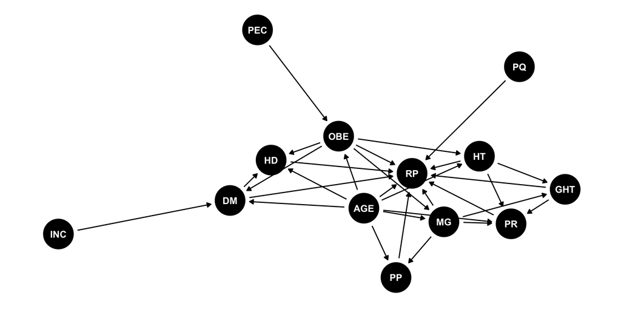

```r
rp_dag <- dagify(
  RP ~ PQ + AGE + OBE + MG + DM + HD + PP + PR + HT + GHT,
  OBE ~ PEC + AGE,
  MG ~ AGE + OBE,
  DM ~ AGE + OBE + INC,
  HD ~ AGE + OBE + DM,
  PP ~ AGE + MG,
  PR ~ AGE + HT + GHT + MG,
  HT ~ AGE + OBE,
  GHT ~ HT + MG
)

rp_dag |>
    ggdag() +
    theme_dag()
```

- RP = “Risk Profile”
- PQ = “Provider Quality”
- AGE = “Age”
- OBE = “Obesity”
- MG = “Multiple Gestation”
- DM = “Diabetes Mellitus”
- HD = “Heart Disease”
- PP = “Placenta Previa”
- PR = “Preeclampsia”
- HT = “Hypertension”
- GHT = “Gestational Hypertension”
- PEC = “Political/Economic Conditions”
- INC = “Income”

## Complete DAG Codification

```r
complete_dag <- dagify(
  RCP ~ PQ + PC + WTP + PT + RA + RP,
  PQ ~ PEC,
  PC ~ DEP + JOB + INC + DIS,
  WTP ~ PQ + INC + INS + RA + CO,
  PT ~ PQ + RE + CO,
  RA ~ PQ + RP + INS,
  RP ~ PQ + AGE + OBE + MG + DM + HD + PP + PR + HT + GHT,
  PEC ~ ST,
  DEP ~ INC + JOB + CO,
  JOB ~ EDU + CO + R + M + I + CC,
  DIS ~ PEC,
  INC ~ JOB + EDU + RE + PEC + AGE,
  INS ~ JOB + PEC + AGE,
  CO ~ PED + PIN + REL + PEC + CC,
  PIN ~ PEC + PED,
  EDU ~ PED + PIN + R + M + I + CC,
  R ~ PR,
  M ~ PM,
  I ~ PI,
  CC ~ PCC,
  REL ~ RE,
  OBE ~ PEC + AGE,
  MG ~ AGE + OBE,
  DM ~ AGE + OBE + INC,
  HD ~ AGE + OBE + DM,
  PP ~ AGE + MG,
  PR ~ AGE + HT + GHT + MG,
  HT ~ AGE + OBE,
  GHT ~ HT + MG
)
```

## Complete DAG Visualization

```r
complete_dag |>
    ggdag() +
    theme_dag()
```

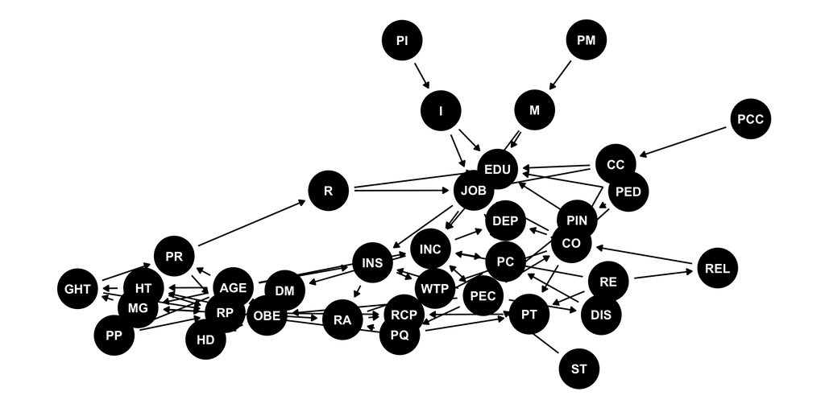

# DAGs and Scientific Complexity

## So What?

- I think it’s worth stepping back and considering how complex many scientific questions really are
- We do not always observe everythign we want to, but with the help of DAGs we can:
  - Identify the variables that are important to the question
  - Identify what we can actually observe
  - Identify what we cannot observe
  - Assess the limitations we face with causal analysis

## Next Steps

- We are now going to work through several applications/case studies, each addressing a different aspect of visualization.

## Side Quest: Simulated Data

- In `examples/dag_sim_data.qmd` we simulated data that encodes the DAG structure.
- Let’s take a very brief glance at that file to see how we simulated the data.

# Worfklow

## Workflow: `ggplot` themes Staying DRY

- In `ggplot_themes_and_staying_dry.qmd` we explore how to make a `ggplot` theme
- We also discuss how to `stay DRY` (Don’t Repeat Yourself) when working with multifile notebooks

## Workflow: Saving Visualizations

- In `saving_visualizations.qmd` I show how to export/save visualizations
- This includes some guidance on file format choices and best practices

# Applications

## Application 1: Effective and Honest Scales

- In `applications_1_effective_and_honest_scales.qmd` we look at how to use scales and position effectively
- We examine how axes can be used to mislead or clarify

## Application 2: Choropleths for Spatial Data

- In `applications_2_choropleths_for_spatial_data.qmd` we create a choropleth map of the United States using the simulated data from above
- We show how even with maps, small multiples help find clarity

## Application 3: Dot Plots for Spatial Data

- In `applications_3_dot_plot_for_spatial_data.qmd` we create a dot plot of the data using the same simulated data.
- We show how spatial variation can often be visualized better without actual maps.

## Application 4: Distribution Plots

- In `applications_4_distribution_plots.qmd` we examine distributions of variables
- We create box plots, violin plots, and ridgeline plots to show the distribution of a variable across a population.

## Application 5: Visualizing Time Trends

- In `applications_5_visualizing_time_trends.qmd` we examine time trends of variables
- We create line plots to show how a variable changes over time.
- We also show how to visualize time trends using a sankey and sunburst plots.

## Application 6: Visualizing Correlations and Models

- In `applications_6_visualizing_correlations_and_models.qmd` we visualize correlations and model outputs
- We’ll look at why it’s important to visualize correlations and model outputs

# Summary and Takeaways

- Visualization choices should be driven by the **scientific question**
- Experimentation is key; often the “obvious” plot is not the best plot
- Iterate: build in layers; get the basics down; then polish
- Use small multiples, annotations, and thoughtful scales to guide the viewer